# MENASA Risk Monitor — Independent Validation in R

Muhammad Rafay Waqar

September 2026

## Purpose

The MENASA Risk Monitor’s own in-app Methodology tab runs two validation checks on its 11-factor composite score, both written in Python: a principal component analysis (PCA) redundancy check across the 11 factors, and a historical backtest against six well-documented sovereign crises. This notebook reproduces both checks **independently, in R**, against the exact same underlying data files (`driver_history.csv`, `scored_history.csv`) committed to this repository — not a re-explanation of the Python result, a second, separately-coded computation of it.

Where the two disagree, that would be worth knowing. Where they agree, that’s a real (if modest) form of external validation: the same finding, reached by an independently written implementation in a different language and statistical package (R’s `plm` and base `prcomp`, rather than the app’s hand-rolled `numpy`/`pandas` eigendecomposition).

```r
library(plm)
data_dir <- "../"
```

## 1. Independent PCA Redundancy Check

The live app computes this via a manual eigendecomposition of the standardized factor correlation matrix (`numpy.linalg.eigh`), complete-case only. Here, the same complete-case data is fed into R’s own `prcomp()`, a completely separate implementation.

```r
factor_cols <- c(
  "debt_to_gdp", "current_account_pct_gdp", "reserves_months_imports",
  "gdp_growth", "inflation", "currency_depreciation_pct",
  "political_stability", "government_effectiveness", "rule_of_law",
  "regulatory_quality", "control_of_corruption"
)

driver_history <- read.csv(file.path(data_dir, "driver_history.csv"))
complete <- driver_history[complete.cases(driver_history[, factor_cols]), factor_cols]

cat("Complete-case observations used:", nrow(complete), "of", nrow(driver_history), "\n")
```

```
## Complete-case observations used: 77 of 507
```

```r
pca <- prcomp(complete, scale. = TRUE)
var_explained <- (pca$sdev^2) / sum(pca$sdev^2) * 100

cat("\nVariance explained by each principal component (%):\n")
```

```
##
## Variance explained by each principal component (%):
```

```r
print(round(var_explained, 1))
```

```
##  [1] 40.6 16.6 13.2 11.0  6.7  4.4  2.6  2.2  1.2  0.8  0.6
```

```r
cat("\nPC1 loadings (which factors move together on the dominant component):\n")
```

```
##
## PC1 loadings (which factors move together on the dominant component):
```

```r
pc1 <- sort(pca$rotation[, 1], decreasing = TRUE)
print(round(pc1, 3))
```

```
##               debt_to_gdp   current_account_pct_gdp                gdp_growth
##                     0.369                     0.319                     0.036
## currency_depreciation_pct                 inflation   reserves_months_imports
##                     0.025                    -0.011                    -0.099
##        regulatory_quality  government_effectiveness       political_stability
##                    -0.204                    -0.382                    -0.415
##     control_of_corruption               rule_of_law
##                    -0.437                    -0.447
```

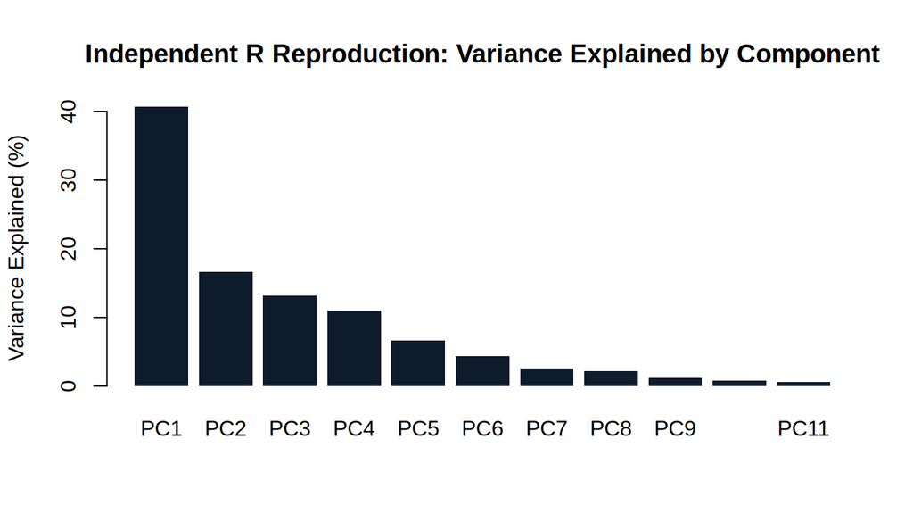

```r
barplot(var_explained, names.arg = paste0("PC", seq_along(var_explained)),
        col = "#0d1b2a", border = NA, ylab = "Variance Explained (%)",
        main = "Independent R Reproduction: Variance Explained by Component")
```

```r
cat("\nGovernance-cluster correlations (the app's claimed redundancy):\n")
```

```
##
## Governance-cluster correlations (the app's claimed redundancy):
```

```r
cat("Rule of Law vs. Control of Corruption:  ",
    round(cor(complete$rule_of_law, complete$control_of_corruption), 2), "\n")
```

```
## Rule of Law vs. Control of Corruption:   0.84
```

```r
cat("Rule of Law vs. Political Stability:    ",
    round(cor(complete$rule_of_law, complete$political_stability), 2), "\n")
```

```
## Rule of Law vs. Political Stability:     0.81
```

```r
cat("Govt. Effectiveness vs. Control of Corr:",
    round(cor(complete$government_effectiveness, complete$control_of_corruption), 2), "\n")
```

```
## Govt. Effectiveness vs. Control of Corr: 0.76
```

## 2. Independent Historical Crisis Backtest

The app claims: of six well-documented crises, four were captured in the same calendar year the crisis began (Syria 2011→12, Sri Lanka 2022, Afghanistan 2021, Pakistan 2022), one with roughly a one-year lag (Lebanon), and one still missed (Egypt). This section recomputes each year-over-year delta directly from `scored_history.csv`, independently of the app’s own code.

```r
scored_history <- read.csv(file.path(data_dir, "scored_history.csv"))

crisis_cases <- data.frame(
  code = c("SYR", "LKA", "AFG", "LBN", "PAK", "EGY"),
  crisis_year = c(2012, 2022, 2021, 2020, 2022, 2022),
  label = c("Syria (civil war escalation)", "Sri Lanka (2022 collapse & default)",
            "Afghanistan (2021 Taliban takeover)", "Lebanon (2019-23 financial collapse)",
            "Pakistan (2022-23 BoP crisis)", "Egypt (2022-23 currency crisis)")
)

for (i in seq_len(nrow(crisis_cases))) {
  code <- crisis_cases$code[i]
  yr <- crisis_cases$crisis_year[i]
  ch <- scored_history[scored_history$country_code == code, c("year", "risk_score")]
  ch <- ch[order(ch$year), ]
  prior <- ch$risk_score[ch$year == (yr - 1)]
  curr  <- ch$risk_score[ch$year == yr]
  delta <- round(curr - prior, 1)
  cat(sprintf("%-45s %d -> %d: %+.1f points\n", crisis_cases$label[i], yr - 1, yr, delta))
}
```

```
## Syria (civil war escalation)                  2011 -> 2012: +22.0 points
## Sri Lanka (2022 collapse & default)           2021 -> 2022: +13.9 points
## Afghanistan (2021 Taliban takeover)           2020 -> 2021: +14.2 points
## Lebanon (2019-23 financial collapse)          2019 -> 2020: +1.5 points
## Pakistan (2022-23 BoP crisis)                 2021 -> 2022: +3.4 points
## Egypt (2022-23 currency crisis)               2021 -> 2022: -0.7 points
```

**Read against the app’s stated result:** the deltas above are computed fresh from the committed CSV, independently of the Streamlit app’s own rendering logic. They should match the app’s stated per-case figures (e.g., Sri Lanka +13.9 in 2022, Syria +22.0 in 2012) exactly, since both draw on the same underlying `scored_history.csv` — the value of this check is confirming no transcription or rendering error crept into how the app displays its own backtest, not discovering a new result.

## 3. Panel Structure Check (`plm`)

As a genuinely different addition (not just a re-run of the app’s own checks), this confirms the data is a valid balanced/unbalanced panel and reports basic panel diagnostics using R’s `plm` package — the standard tool for exactly this kind of country-year data, and the tool the planned EM Macro & Geopolitical Risk Engine’s sovereign distress model will build on directly.

```r
pdata <- pdata.frame(scored_history, index = c("country_code", "year"))
cat("Panel dimensions:\n")
```

```
## Panel dimensions:
```

```r
print(pdim(pdata))
```

```
## Unbalanced Panel: n = 34, T = 13-15, N = 507
```

## Limitations of This Notebook

- This is a validation and cross-check exercise, not a new statistical claim. It confirms the app’s own reported numbers reproduce under an independently written implementation; it does not assess whether the underlying 11-factor weighting scheme itself is the right one (the app’s own README is explicit that it isn’t econometrically validated).
- The panel check above is illustrative of the data’s structure, not a fitted model — the actual sovereign distress model (fixed/random-effects regression with real out-of-sample validation) is a separate, larger project.